# R Notebook

### Importamos librearias a utilizar

```r
library(tidyverse)
```

### Cargamos nuestro dataset

```r
fish <- read_csv("Fish.csv")
```

Comenzamos entonces haciendo un subset de datos que incluya las variables que vamos a utilizar, en nuestro caso utilizaremos las variables:

- Species
- Length1
- Weight

Por comodidad, vamos a renombrar las columnas a utilizar de la siguiente manera:

- species = Species
- length = Length1
- weight = Weight

```r
# Subset de datos que incluye solo los peces cuya especie es "Bream"
bream <- fish %>%
  filter(Species == "Bream")
```

```r
# Seleccionamos solamente las tres variables a utilizar, y aprovechamos a cambiar nombre a dichas
# variables
bream <- bream %>%
  select(species = Species, length = Length1, weight = Weight)
```

Podemos comenzar haciendo un gráfico para ver la relación entre las variables Longitud y Peso. En la gráfica le indicamos a ggplot que dibuje una linea que se ajuste al modelo de regresión lineal.

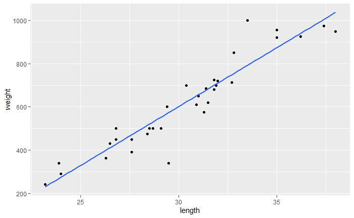

```r
ggplot(bream, aes(length, weight)) +
  geom_point() +
  geom_smooth(method = "lm", se = FALSE)
```

```r
  # lm = linear model
  # se = FALSE para que no muestre la banda de intervalo de confianza
```

Podemos observar que hay una cierta relación lineal entre las variables. Su dirección es en diagonal hacia arriba. Pareciera que por cada cierto desplazamiento en la variable *length* hay un cierto desplazamiento en la variable *weight*. Notese que la escala de la variable *length* (centimetros) es diferente de la escala de la variable *weight* (gramos).

El objetivo de la regresión lineal es que la distancia entre los puntos observados y los puntos estimados (la linea estimada) sea lo mínimo posible. Es decir es un problema de optimización: Minimizar la distancia entre los puntos observados y los puntos estimados.

La linea de regresión es la linea en la cual el error de todos los puntos es mínimo. ggplot lo hace con el método de mínimos cuadrados.

Dado que nosotros no tenemos acceso a todos los parámetros del modelo de regresión lineal que ggplot generó, entonces procedemos a crear nuestro propio modelo de regresión lineal. Para ello utilizamos la función *lm* para crear (entrenar) nuestro modelo. Especificamos la variable dependiente *weight* y la variable independiente *length*

```r
mdl_weight_vs_length <- lm(formula = weight ~ length, data=bream)
print(mdl_weight_vs_length)
```

[output not shown]

Vemos que la función nos devuelve los coeficientes:

### Haciendo predicciones con nuestro modelo

La idea del modelo creado es poder hacer predicciones. Entonces vemos como le enviamos datos nuevos a evaluar con nuestro modelo.

Si vemos nuestro subset de datos *bream* podemos observar que tenemos *length* desde el 23.2 hasta el 38.0, pero dentro de ese rango no están todos los valores posibles, por ejemplo, falta valores de *length* de 25, 34, entre otros.

Entonces, vamos a crear un dataframe con la función *tibble* que contenga una columna *length* con valores de 20 a 40.